# Wind rose plot

*Raynaldi Pratama*

03/03/2021

**Notes:** This portfolio presents the steps to create wind rose visualizations based on Bilbao-Vizcaya buoy data records, including some techniques to handle missing values within the dataset. These techniques were introduced by **Matt Dancho** of [Business Science](https://www.business-science.io/) through his Free R-Tips, which can be found [here](https://github.com/business-science/free_r_tips).

**Library setup:**

```r
# Quickly visualizing data
library(visdat)

# Working with NA's
library(naniar)

# Simple imputation
library(simputation)
library(randomForest)

# Manipulating and analysing data
library(tidyverse)

# Wind rose plot
library(openair)
```

## Bilbao-Vizcaya buoy data

### Load the data

```r
buoydata <- read.table("BilbaoVizcaya.txt", header = TRUE) # Find the coresponding file inside 00_data/

buoydata <- buoydata %>%
  filter(buoydata$AA > "2009") # To obtain the best records and to avoid a whole-year missing data

summary(buoydata)
```

```
##        AA             MM               DD              HH
##  Min.   :2010   Min.   : 1.000   Min.   : 1.00   Min.   : 0.00
##  1st Qu.:2011   1st Qu.: 4.000   1st Qu.: 8.00   1st Qu.: 5.75
##  Median :2012   Median : 6.000   Median :16.00   Median :12.00
##  Mean   :2012   Mean   : 6.467   Mean   :15.67   Mean   :11.50
##  3rd Qu.:2013   3rd Qu.: 9.000   3rd Qu.:23.00   3rd Qu.:17.00
##  Max.   :2014   Max.   :12.000   Max.   :31.00   Max.   :23.00
##
##       Hm0              Tm02              Tp              Hmax
##  Min.   : 0.000   Min.   : 2.600   Min.   : 0.000   Min.   : 0.000
##  1st Qu.: 1.000   1st Qu.: 4.700   1st Qu.: 7.700   1st Qu.: 1.600
##  Median : 1.600   Median : 5.700   Median : 9.600   Median : 2.400
##  Mean   : 1.843   Mean   : 5.902   Mean   : 9.449   Mean   : 2.849
##  3rd Qu.: 2.300   3rd Qu.: 6.900   3rd Qu.:11.100   3rd Qu.: 3.500
##  Max.   :10.100   Max.   :13.600   Max.   :22.300   Max.   :16.100
##  NA's   :59       NA's   :61       NA's   :59       NA's   :2741
##      Thmax           Pro_Oe           Dmd            Dmd_P
##  Min.   : 0.00   Min.   :1.000   Min.   :  0.0   Min.   :  0.0
##  1st Qu.: 7.20   1st Qu.:1.000   1st Qu.:295.0   1st Qu.:295.0
##  Median : 9.20   Median :1.000   Median :307.0   Median :305.0
##  Mean   : 9.16   Mean   :1.133   Mean   :288.6   Mean   :290.9
##  3rd Qu.:11.00   3rd Qu.:1.000   3rd Qu.:319.0   3rd Qu.:316.0
##  Max.   :22.40   Max.   :3.000   Max.   :360.0   Max.   :360.0
##  NA's   :2741                    NA's   :1475    NA's   :59
##       Ds_P           Pro_Od          Ts2                Sa2
##  Min.   :10.00   Min.   :1.000   Length:39916       Length:39916
##  1st Qu.:23.00   1st Qu.:1.000   Class :character   Class :character
##  Median :28.00   Median :1.000   Mode  :character   Mode  :character
##  Mean   :29.28   Mean   :1.133
##  3rd Qu.:34.00   3rd Qu.:1.000
##  Max.   :79.00   Max.   :3.000
##  NA's   :2743
##     Vc_md              Dc_md              Pro_Oce            Ps
##  Length:39916       Length:39916       Min.   :2.000   Min.   : 976
##  Class :character   Class :character   1st Qu.:2.000   1st Qu.:1012
##  Mode  :character   Mode  :character   Median :2.000   Median :1017
##                                        Mean   :2.064   Mean   :1016
##                                        3rd Qu.:2.000   3rd Qu.:1021
##                                        Max.   :3.000   Max.   :1038
##                                                        NA's   :4442
##        Ta            Vv_md            Dv_md          Pro_Met
##  Min.   : 2.20   Min.   : 0.000   Min.   :  0.0   Min.   :2.000
##  1st Qu.:12.50   1st Qu.: 2.500   1st Qu.: 90.0   1st Qu.:2.000
##  Median :15.80   Median : 4.400   Median :202.0   Median :2.000
##  Mean   :15.69   Mean   : 4.874   Mean   :191.5   Mean   :2.064
##  3rd Qu.:19.30   3rd Qu.: 6.700   3rd Qu.:286.0   3rd Qu.:2.000
##  Max.   :27.30   Max.   :19.600   Max.   :357.0   Max.   :3.000
##  NA's   :2       NA's   :91       NA's   :5996
##       Qc_e
##  Min.   :1.000
##  1st Qu.:1.000
##  Median :1.000
##  Mean   :1.042
##  3rd Qu.:1.000
##  Max.   :9.000
##
```

### Wind speed and direction

```r
year <- buoydata$AA

month <- buoydata$MM

day <- buoydata$DD

hour <- buoydata$HH

wind_spd <- buoydata$Vv_md

wind_dir <- buoydata$Dv_md

wind_df <- data.frame(year, month, day, hour, wind_spd, wind_dir)

wind_df_tbl <- wind_df %>% as_tibble()

wind_df_tbl
```

```
## # A tibble: 39,916 x 6
##     year month   day  hour wind_spd wind_dir
##    <int> <int> <int> <int>    <dbl>    <dbl>
##  1  2010     1     1     0     15.2      261
##  2  2010     1     1     1     15        261
##  3  2010     1     1     2     14.7      261
##  4  2010     1     1     3     14.2      267
##  5  2010     1     1     4     13.8      264
##  6  2010     1     1     5     13.5      270
##  7  2010     1     1     6     12.8      264
##  8  2010     1     1     7     11.9      267
##  9  2010     1     1     8     11        270
## 10  2010     1     1     9      9.3      247
## # ... with 39,906 more rows
```

## Missing data visualizations

### **`vis_dat()`** command

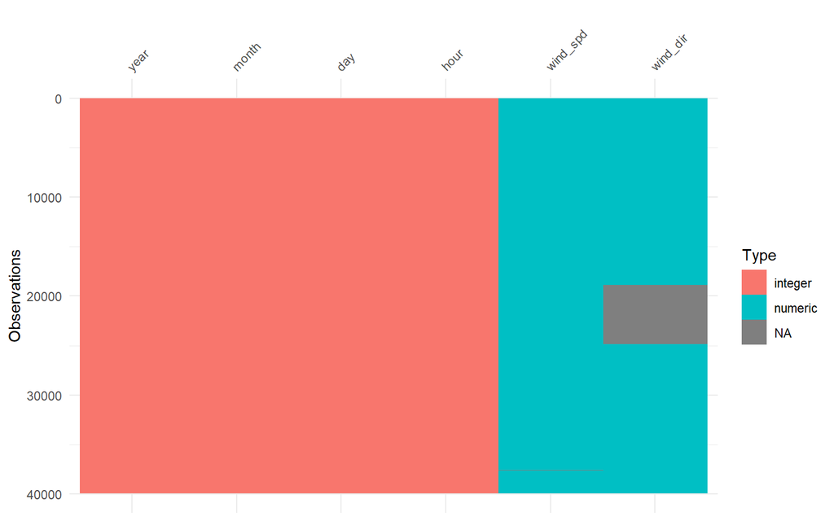

```r
wind_df_tbl %>% vis_dat()
```

From the figure above, the missing values occur at around the observation number 20000 to 25000. We can also see the portion of the NAs in grey against the whole recorded data. However, this figure fails to show the percentage of the NAs contained within this particular dataset.

### **`vis_mis()`** command

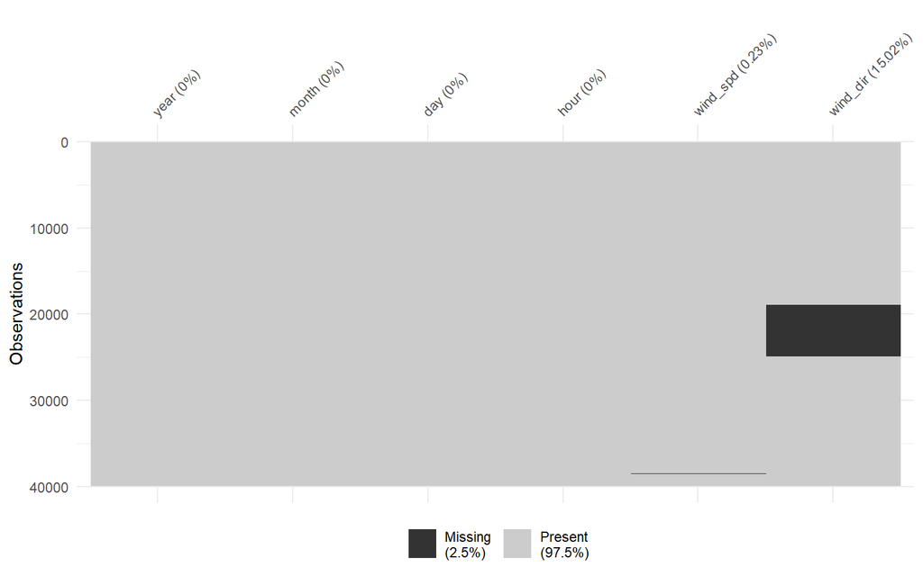

```r
wind_df_tbl %>% vis_miss()
```

To fill the information gap from the previous figure, another visualization, as depicted in the figure above, may also be considered. From this figure, we can get a clear percentage of missing values in our dataset, both for wind speed and wind direction.

### **`gg_miss_upset()`** command

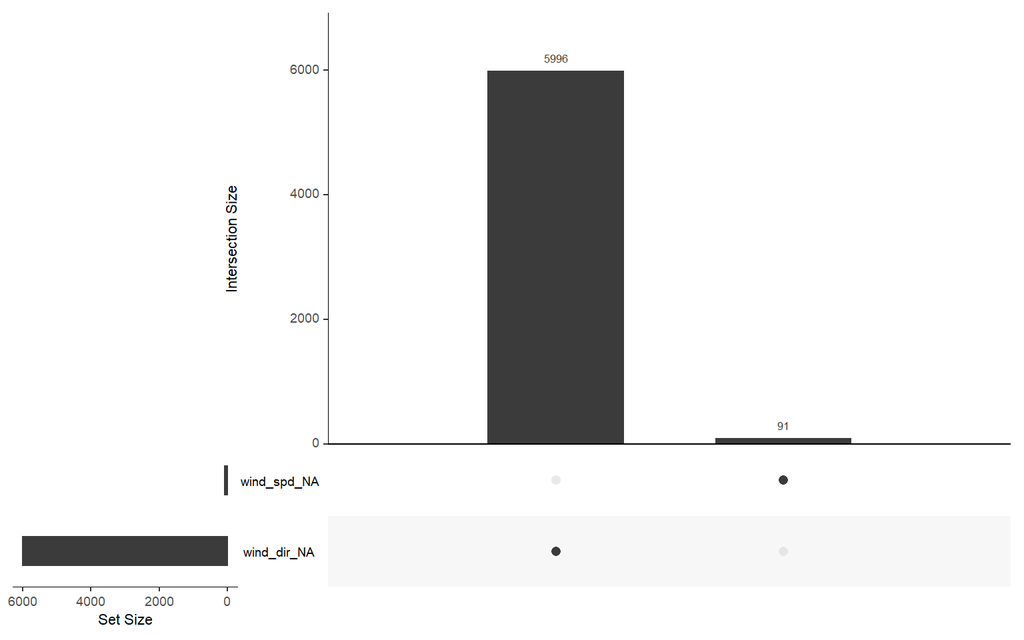

```r
wind_df_tbl %>% gg_miss_upset()
```

The figure above meant to visualize the correlation between the missing data from both categories, wind speed and wind direction. If there was any correlation presented in this figure, there was likely an issue with the sensor that may be happened during the observation. However, in this case, missing values in both categories are just a common case since they are independent of each other.

### **`geom_miss_point()`** command

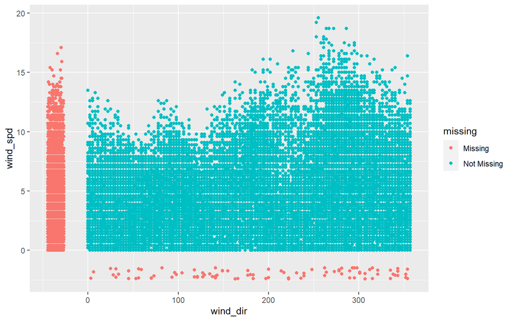

```r
wind_df_tbl %>%
  ggplot(aes(x = wind_dir, y = wind_spd)) +
  geom_miss_point()
```

We can see how all recorded data corresponding to wind speed and wind direction are distributed from the figure above. Off all the visualized data, we can also see the visualization of missing values in red dots from both data categories. There are depicted missing values for wind direction to the left part of the figure, while the lower part of the figure shows some missing values for wind speed.

## Missing data imputation

### Linear model imputation

Below are codes written to perform a simple imputation to replace missing values for wind direction using the linear model imputation method, **`impute_lm()`**. In this case, the missing values will be replaced with new values that follow the linear model as a wind speed function (and month). We might want to consider “month” to give a good sense of wind direction variation during the whole year records.

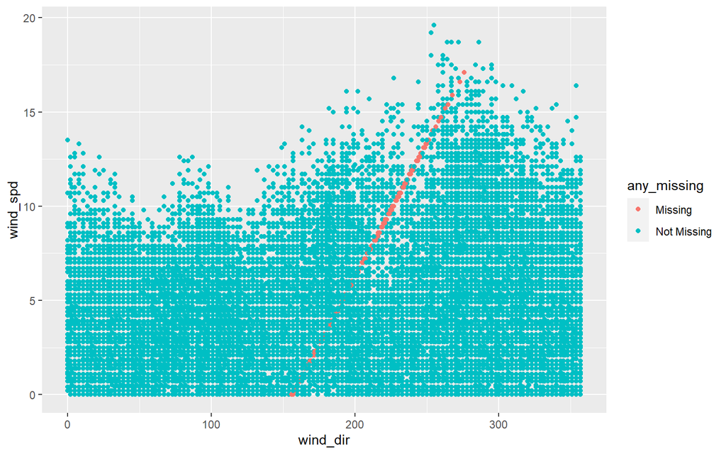

```r
wind_df_tbl %>%

  # Label if wind_spd is missing
  add_label_missings(wind_dir) %>%

  # Imputation - Linear Regression
  impute_lm(wind_dir ~ wind_spd + month) %>%

  # Visualize
  ggplot(aes(wind_dir, wind_spd, color = any_missing)) +
  geom_point()
```

### Random forest imputation

Below are codes written to perform a simple imputation to replace missing values for wind direction using the random forest imputation method, **`impute_rf()`**. As it is explained previously, the missing values will be replaced by some values that matched a certain model; here is a random forest, using wind direction as a function of wind speed and month.

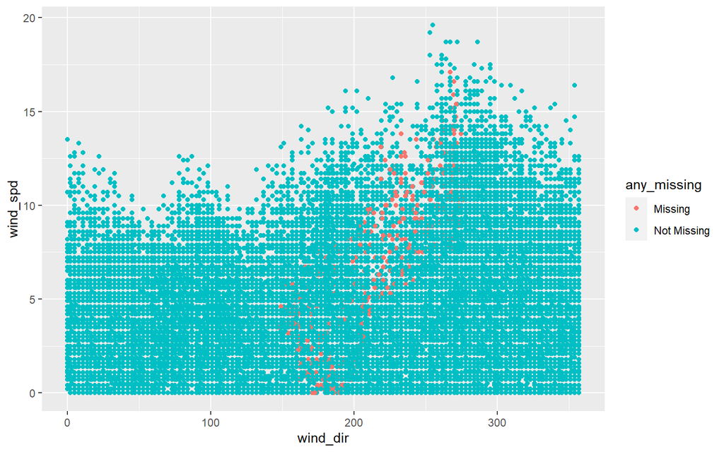

```r
wind_df_tbl %>%

  # Label if wind_spd is missing
  add_label_missings(wind_dir) %>%

  # Imputation - Random Forest
  impute_rf(wind_dir ~ wind_spd + month) %>%

  # Visualize
  ggplot(aes(wind_dir, wind_spd, color = any_missing)) +
  geom_point()
```

### Save the result as an object

```r
wind_df_tbl_fixed <- wind_df_tbl %>%

  # Label if wind_spd is missing
  add_label_missings(wind_dir) %>%

  # Imputation - Random Forest
  impute_rf(wind_dir ~ wind_spd + month)
```

## Wind rose plot

Follow these steps to plot the wind rose to visualise how the wind blows in a particular area with a specific velocity and direction during the extreme seasons, winter and summer. The results can be compared to the one provided on the Spanish authorities website, [Puertos del Estado](http://www.puertos.es/en-us/oceanografia/Pages/portus.aspx), by specifying the exact period of observation. The method used to handle the NA’s value in the following script has been mentioned in the earlier section. The only addition is that we need to specify which months belong to each season. In this case, “DEC-JAN-FEB” belongs to winter, while “JUN-JUL-AUG” belongs to summer as a standard convention being used.

Go to [this link](https://davidcarslaw.github.io/openair/reference/windRose.html) to get familiar with the wind rose plot.

### Plot for winter wind data

```r
winter_df <- wind_df_tbl_fixed %>%
  filter(wind_df_tbl_fixed$month == 12 |
    wind_df_tbl_fixed$month == 1 |
    wind_df_tbl_fixed$month == 2) # DEC-JAN-FEB

winter_df
```

```
## # A tibble: 7,755 x 7
##     year month   day  hour wind_spd wind_dir any_missing
##    <int> <int> <int> <int>    <dbl>    <dbl> <chr>
##  1  2010     1     1     0     15.2      261 Not Missing
##  2  2010     1     1     1     15        261 Not Missing
##  3  2010     1     1     2     14.7      261 Not Missing
##  4  2010     1     1     3     14.2      267 Not Missing
##  5  2010     1     1     4     13.8      264 Not Missing
##  6  2010     1     1     5     13.5      270 Not Missing
##  7  2010     1     1     6     12.8      264 Not Missing
##  8  2010     1     1     7     11.9      267 Not Missing
##  9  2010     1     1     8     11        270 Not Missing
## 10  2010     1     1     9      9.3      247 Not Missing
## # ... with 7,745 more rows
```

```r
windRose(winter_df,
  ws = "wind_spd",
  wd = "wind_dir",
  ws.int = 4,
  angle = 22.5,
  cols = "hue",
  paddle = FALSE
)
```

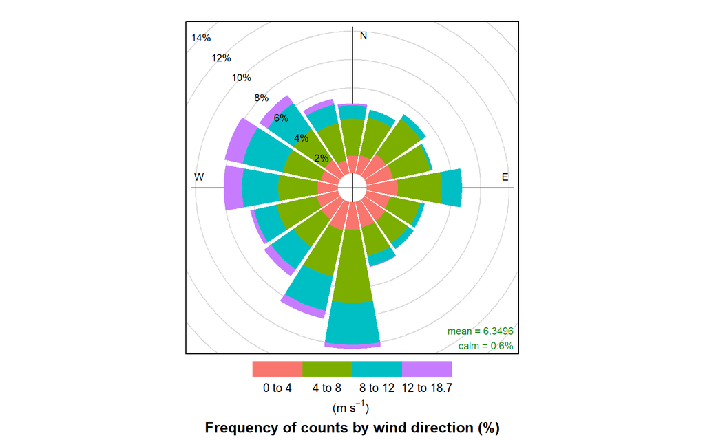

### Plot for summer wind data

```r
summer_df <- wind_df_tbl_fixed %>%
  filter(wind_df_tbl_fixed$month == 6 |
    wind_df_tbl_fixed$month == 7 |
    wind_df_tbl_fixed$month == 8) # JUN-JUL-AUG

summer_df
```

```
## # A tibble: 11,039 x 7
##     year month   day  hour wind_spd wind_dir any_missing
##    <int> <int> <int> <int>    <dbl>    <dbl> <chr>
##  1  2010     6     1     0      0.2      261 Not Missing
##  2  2010     6     1     1      2.8      343 Not Missing
##  3  2010     6     1     2      2.8      340 Not Missing
##  4  2010     6     1     3      1.6      320 Not Missing
##  5  2010     6     1     4      0.9      309 Not Missing
##  6  2010     6     1     5      0.9      323 Not Missing
##  7  2010     6     1     6      0.7       64 Not Missing
##  8  2010     6     1     7      1.6      337 Not Missing
##  9  2010     6     1     8      0.9      357 Not Missing
## 10  2010     6     1     9      1.6        2 Not Missing
## # ... with 11,029 more rows
```

```r
windRose(summer_df,
  ws = "wind_spd",
  wd = "wind_dir",
  ws.int = 4,
  angle = 22.5,
  cols = "hue",
  paddle = FALSE
)
```

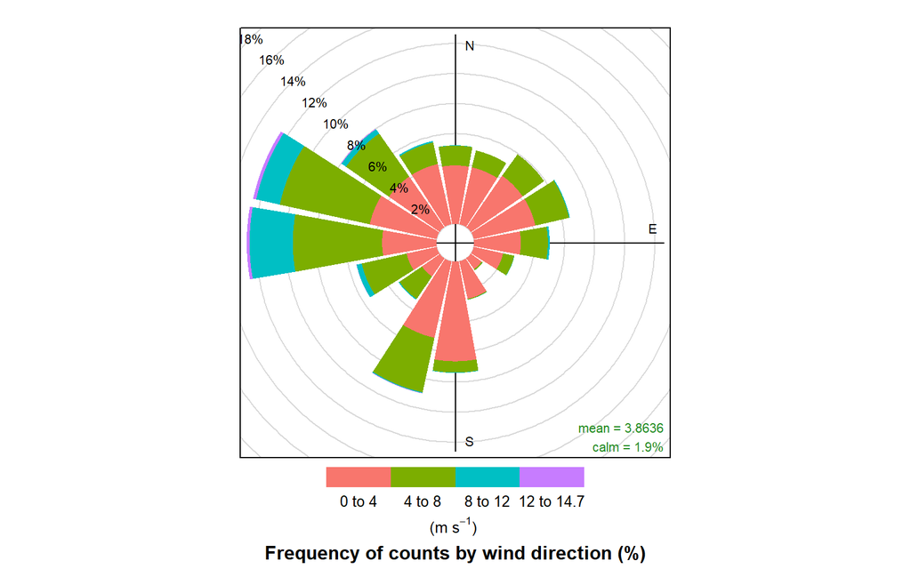